# Project: Investigate a Dataset (TMDb Movie Data)

## Question 4 : Which variables have the strongest positive relationship?

Does popularity depends on budget of a movie? To answer this question we gonna visualize some scatterplots and we will find the correlations between them.

### Scatterplot profit vs release year

[figure not shown]

```python
x = df['release_year']
y = df['profit']

#we add title, ylabel and xlabel in the plot
plt.figure(figsize=(20,10))
plt.xlabel('budget')
plt.ylabel('popularity')
plt.title('Scatterplot for popularity vs budget')
plt.scatter(x, y, alpha=0.4);
plt.show(block=True);
```

```python
data_corr = df.corr()
print("Correlation Between profit And release_year : ",data_corr.loc['profit','release_year'])
```

```
Correlation Between profit And release_year :  0.05704803214590645
```

### Scatterplot for popularity vs budget

[figure not shown]

```python
x = df['popularity']
y = df['budget']

#we add title, ylabel and xlabel in the plot
plt.figure(figsize=(20,10))
plt.xlabel('budget')
plt.ylabel('popularity')
plt.title('Scatterplot for popularity vs budget')
plt.scatter(x, y, alpha=0.4);
plt.show(block=True);
```

```python
print("Correlation Between Popularity And Budget : ",data_corr.loc['popularity','budget'])
```

```
Correlation Between Popularity And Budget :  0.5454722315501995
```

The relationship between popularity and budget is positive but not strong.

### Scatterplot for profit vs budget

[figure not shown]

```python
x = df['profit']
y = df['budget']

#we add title, ylabel and xlabel in the plot
plt.figure(figsize=(20,10))
plt.xlabel('budget')
plt.ylabel('popularity')
plt.title('Scatterplot for popularity vs budget')
plt.scatter(x, y, alpha=0.4);
plt.show(block=True);
```

```python
print("Correlation Between profit And budget is : ",data_corr.loc['profit','budget'])
```

```
Correlation Between profit And budget is :  0.7349006819075996
```

We have a strong positive relationship between budget and profit which we can observe from the scatterplot as well.

### Scatterplot for popularity vs vote_average

[figure not shown]

```python
x = df['popularity']
y = df['vote_average']

plt.figure(figsize=(20,10))

plt.title('Scatterplot for popularity vs vote average')
plt.xlabel('Profit')
plt.ylabel('vote average')
plt.scatter(x, y, alpha=0.5);
plt.show(block=True);
```

```python
print("Correlation Between popularity And vote_average : ",data_corr.loc['popularity','vote_average'])
```

```
Correlation Between popularity And vote_average :  0.2095113074753999
```

We have a weak positive relationship between popularity and vote_average.

### Scatterplot for profit vs vote_average

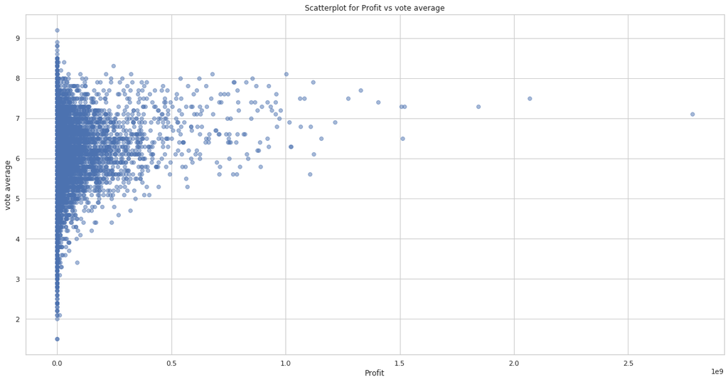

```python
x = df['profit']
y = df['vote_average']

plt.figure(figsize=(20,10))

plt.title('Scatterplot for Profit vs vote average')
plt.xlabel('Profit')
plt.ylabel('vote average')
plt.scatter(x, y, alpha=0.5);
plt.show(block=True);
```

```python
print("Correlation Between profit And vote_average : ",data_corr.loc['popularity','budget'])
```

[output not shown]

We can see that the correlation is positive but the relationship is not strong.

### Scatterplot for duration vs budget

Is duration of a movie correlated with the budget?

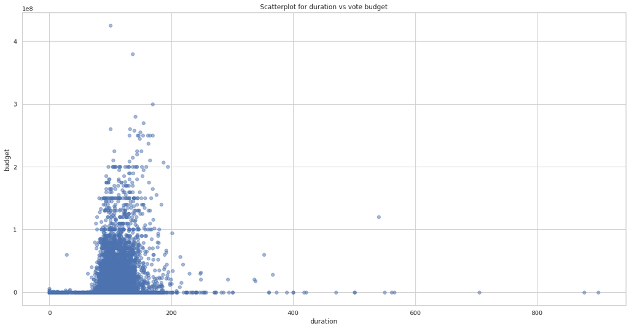

```python
x = df['duration']
y = df['budget']

plt.figure(figsize=(20,10))

plt.title('Scatterplot for duration vs vote budget')

plt.xlabel('duration')
plt.ylabel('budget')
plt.scatter(x, y, alpha=0.5);
plt.show(block=True);
```

```python
print("Correlation Between budget And duration of a movie: ",data_corr.loc['duration','budget'])
```

```
Correlation Between budget And duration of a movie:  0.19128265656578128
```

We can see that budget and duration are not strongly correlated however they are not negative correlated. That means that budget can be low or high in a long or short movie as well.

If we want to visualize our findings about correlation in order to see the most strong relationship between the variables, we can visualise them with a correlation matrix which is a table showing correlation coefficients between variables.

```python
#We define the function plot_correlation_map in order to vizualise the correlation of the variables
#and find the strongest one.
def plot_correlation_map( df ):
    corr = df.corr()
    _ , ax = plt.subplots( figsize =( 12 , 10 ) )
    cmap = sns.diverging_palette( 240 , 10 , as_cmap = True )
    _ = sns.heatmap(corr,cmap = cmap,square=True, cbar_kws={ 'shrink' : .9 }, ax=ax, annot = True, annot_kws = { 'fontsize' : 12 })
```

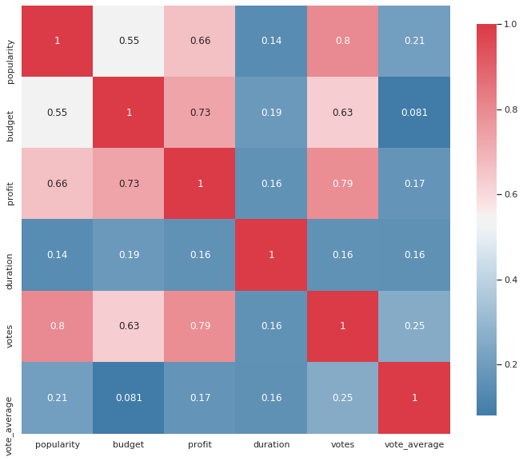

```python
plot_correlation_map(df[['popularity','budget','profit','duration','votes','vote_average']])
```

- Budget vs profit : They have a strong relationship of 0.73
- Popularity vs profit : They have a positive relationship of 0.66. This shows that there is a good possibility that most popular films tend to have better profits.
- Duration vs profits: The relationship is really weak 0.16. It seems that movie duration is not affecting the movie profits. This could be the reason that movies length is decreasing through the years.

### Question 5: How profit increases through the years?

We will now plot the increase of the movie's profit as years go by.

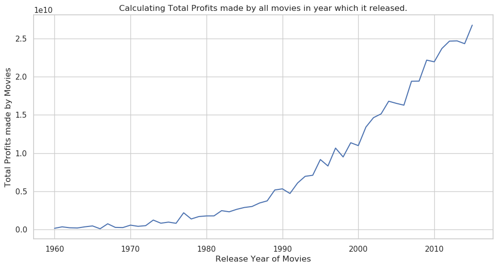

```python
#We calculate the summary of each year's profit.
profits_each_year = df.groupby('release_year')['profit'].sum()
plt.figure(figsize=(12,6), dpi = 100)

#Setting the x label
plt.xlabel('Release Year of Movies', fontsize = 12)
#Setting the y axis
plt.ylabel('Total Profits made by Movies', fontsize = 12)
#title of a the plot
plt.title('Calculating Total Profits made by all movies in year which it released.')

#plotting the variable we created for the summary of profit.
plt.plot(profits_each_year)

#Visualize the result
plt.show()
```

It's obvious that movie profits increase is incredible and especially after 00s we see an enormous increase. We can observe that during 60s and 70s movies profit was extremely low. That explains the fact that all the high budget movies where during the 00s. And high profit as well. The main cause could be the fact that humanity tends to get richer so the movies do.

### Question 6: Which genres are most popular from year to year?

In order to find out the most popular genres throught the years, we will construct a new dataframe that separates the genres and then calculate the number of movies in each genre. Then we will visualise our results in order to see the most popular genre throught the years. The best way to visualize our findings will be a bar chart and a pie chart. We will use matplotlib in order to extract the charts that we want.

```python
#In order to find the most popular genres per year we construct df_split_genre
df_split_genre = df.copy()
#In order to find the most popular genres per year we define the function df_split_genre
#remove the ('|') from the genres column
split_genre = df_split_genre['genres'].str.split('|').apply(pd.Series, 1
).stack().reset_index(level=1, drop=True)

split_genre.name = 'genre_split'
df_split_genre = df_split_genre.drop(['genres'], axis=1).join(split_genre)
```

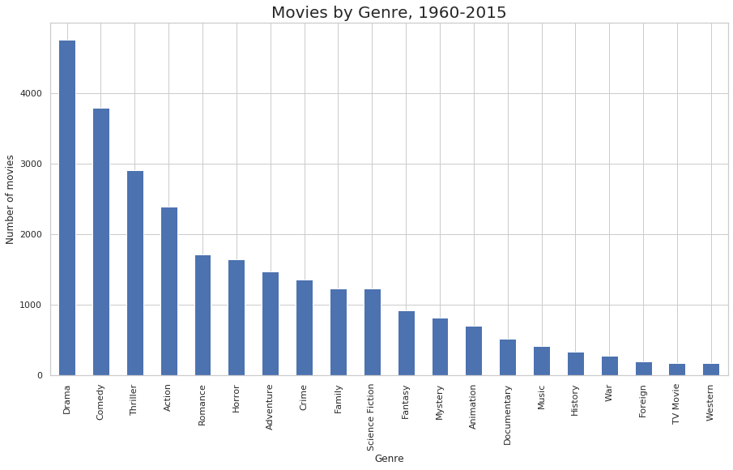

```python
#plot the result in a barchart
df_split_genre['genre_split'].value_counts().plot(kind='bar', figsize=(15, 8));
#Adding plot title
plt.title('Movies by Genre, 1960-2015', size=20)
plt.xlabel('Genre', size=12)
plt.ylabel('Number of movies', size=12);
```

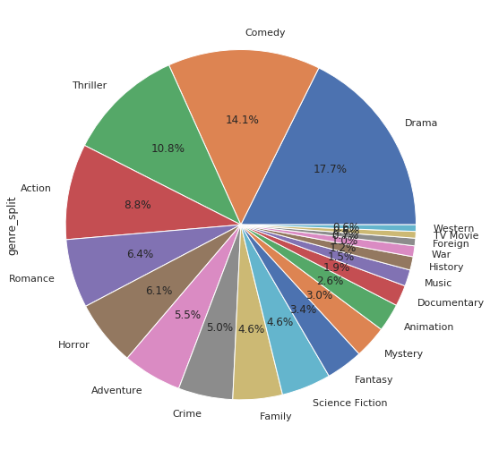

```python
df_split_genre['genre_split'].value_counts().plot(kind='pie', figsize=(9,9), autopct="%1.1f%%");
```

We can visualise our result with a pie chart as well that calculates the percentage of the genres popularity. We can see that drama is the most popular genre all those years. Comedy is 2nd and thriller 3rd. Those are the movie genres that people prefer. We can also visualize our results in a pie chart and see the percentages as well.

### Question 7 Which is the average duration of the movies during all those years?

```python
dur = df['duration'].mean()
print ('The average movie duration is:', dur)
```

```
The average movie duration is: 102.07086324314375
```

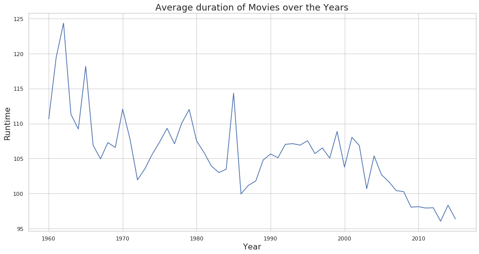

```python
df.groupby('release_year')['duration'].mean().plot(figsize = (16, 8), color = 'b')
plt.title('Average duration of Movies over the Years', fontsize = 18)
plt.xlabel('Year', fontsize = 16)
plt.ylabel('Runtime', fontsize = 16)
sns.set_style("whitegrid");
```

### Question 8: Which keywords appear the most in this dataset?

```python
from wordcloud import WordCloud, STOPWORDS
```

```python
%matplotlib inline
df_split_keys = df.copy()
#remove the ('|') from the keywords column
split_keys = df_split_keys['keywords'].str.split('|').apply(pd.Series, 1
).stack().reset_index(level=1, drop=True)
split_keys.name = 'keys_split'
#this is for the keywords data
df_split_keys = df_split_keys.drop(['keywords'], axis=1).join(split_keys)
```

We can visualize our results in a pie chart with some of the keywords.

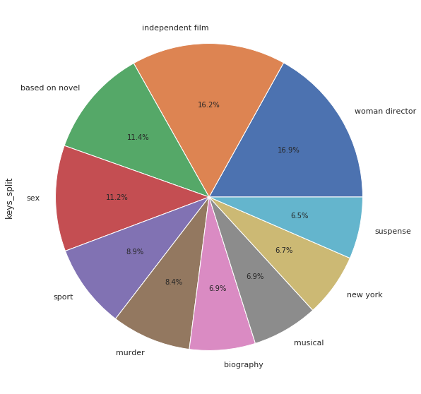

```python
df_split_keys['keys_split'].value_counts().nlargest(10).plot(kind='pie', figsize=(10,10), autopct="%1.1f%%");
```

```python
df_split_keys['keys_split'].tail(50)
```

```
10850                  private eye
10850                   lew harper
10851    parents kids relationship
10851                 famous score
10851                         lion
10851         aggression by animal
10851                  dead animal
10852                   poker game
10853                    womanizer
10853                      playboy
10854                      sheriff
10854                  house party
10854                     man hunt
10854                     junkyard
10854              jump from train
```

[output cut: 36 more lines]

## Limitations

Although we cleaned our data, there were still some things that we needed to consider:

- We have used TMBD Movies dataset for our analysis and worked with popularity, revenue and runtime. Our analysis is limited to only the provided dataset. For example, the dataset does not confirm that every release of every director is listed.
- Maybe we could expand our analysis with more data movies from other databases. IMDB would be a good case.
- We were not normalized or exchanged the currency conversion during this analysis, we were just limited to the numerical values of revenue.
- Dropping missing or Null values from variables of our interest might skew our analysis and could show unintentional bias towards the relationship being analyzed. etc.
- We were not able to find a really strong relationship in terms of correlation between the popularity and the popularity and vote average. This could be further investigated because the logic says that popular films should have more votes. This could be due to the 0s that we chose not to drop (this could skew our analysis and we would possibly not be able to collect good results.)
- We were not be able to find a relationship between duration and profits. This could be the reason that directors choose to direct short films. Or maybe short films are easier to watch? Longer films could make the audience tired sooner. This could be further analysed in the future.